# EDA_exec_summary

Gillian Haggerty

12/6/2019

## R Markdown

This data compiled from the World Health Organization (WHO) and the United Nations (UN) contains information on the life expectancy of a given population collected for 193 countries from 2000-2015. Each country is evaluated by 17 metrics including health factors like the prevalence of diseases including Hepatitis B, HIV/AIDS, and measles, as well as economic factors such as GDP and percentage expenditure.  
My analyses were focused on a few specific areas: economic prosperity and expenditure and what relationships were meaningful with health factors, is there anything to be learned from alcohol consumption and life expectancy, and understanding how comparisons can be made between developing and developed countries.  
An important conclusion I came to in my analysis regarding economic factors was how income composition of resources, GDP, and schooling interacted with one another and could be used as predictive variables for life expectancy. The relationship between GDP and life expectancy was not telling at all, and in fact, income composition of resources had a positive correlation with the latter as did schooling. When compared to one another, schooling and income composition of resources showed to also have a strong positive correlation with a high density along a linear relationship and showing a linear spread.

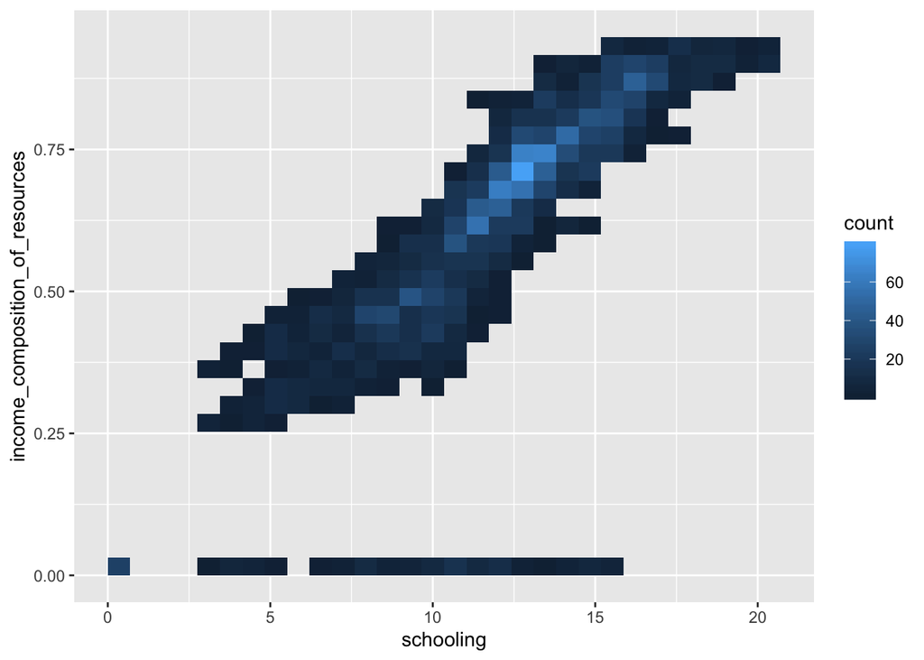

What is particularly informative in this graph is that it shows dimension–unlike other graphs that may represent the relationship with just a collection of points or a single line, this plot shows the highest density trend and has a linear spread.  
Income composition is a rather tailored economic variable which led me to wonder about the impact of GDP which is arguably broader. The relationship between income composition and GDP was interesting to me as it demonstrates the difference in what the data represents. While the two variables seemingly measure similar things, the disparity highlights the difference in what it measures. The former measures an individual’s quality of life economically as opposed to national economic growth. Looking at a 2d bin graph demonstrates how the metrics can be at odds.

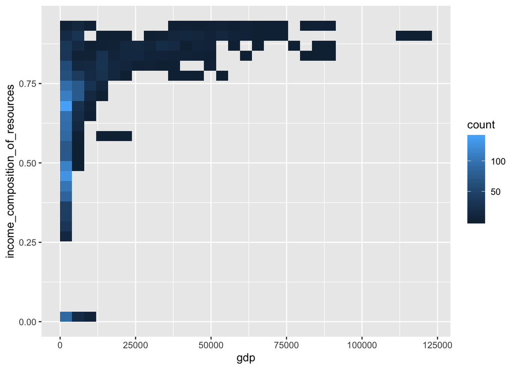

The economic lens on this analysis can help inform where policy should start. The UN developed the income composition index to “question national policy choices.” While the data demonstrated clear inaccuracies and required a lot of interpretation, the results of this EDA can still be useful.

Citation: Kumar Rajarshi. (2018). Life Expectancy (WHO) Statistical Analysis on factors influencing Life Expectancy. Available from Kaggle: https://www.kaggle.com/kumarajarshi/life-expectancy-who